# STA206 Fall 2021: Quiz3 Question 2

**Instruction**:

- In this question, you will be asked to perform some tasks in R
- You should submit a .html or .pdf or .docx file

In *Quiz3_data_Q2.Rdata*, you will find a data set called **data** with 6 variables: *Y, V1, V2, V3, V4, V5*. The goal is to use **data** to build a model of *Y* using *V1,…,V5* as (potential) predictors. Note that, you may need to transform the response variable *Y*.

- **(a). Load the data into the R workspace.**

```r
load("C:/Users/kevin/Downloads/Quiz3_data_Q2.Rdata")
```

- **(b). Check variable type for each variable and convert $V1$ to a factor.**

```r
sapply(data, class)
```

```
##         Y        V1        V2        V3        V4        V5
## "numeric" "numeric" "numeric" "numeric" "numeric" "numeric"
```

```r
data[,2] <- as.factor(data[,2])
sapply(data, class)
```

```
##         Y        V1        V2        V3        V4        V5
## "numeric"  "factor" "numeric" "numeric" "numeric" "numeric"
```

- **(c). Fit the 1st-order model. Does this model suggest any transformation?**

```r
Model1 <- lm(Y~., data = data)
summary(Model1)
```

```
##
## Call:
## lm(formula = Y ~ ., data = data)
##
## Residuals:
##       Min        1Q    Median        3Q       Max
## -0.077527 -0.016070  0.000203  0.014569  0.088103
##
## Coefficients:
##               Estimate Std. Error t value Pr(>|t|)
## (Intercept)  1.542e+00  3.779e-02  40.797  < 2e-16 ***
## V12          4.059e-02  1.451e-02   2.798  0.00566 **
## V13         -3.424e-03  9.442e-03  -0.363  0.71729
## V2           4.217e-05  7.193e-05   0.586  0.55841
## V3          -4.218e-04  1.407e-04  -2.997  0.00308 **
## V4          -4.907e-03  7.420e-04  -6.613 3.61e-10 ***
## V5          -1.565e-03  1.166e-03  -1.343  0.18093
## ---
## Signif. codes:  0 '***' 0.001 '**' 0.01 '*' 0.05 '.' 0.1 ' ' 1
##
## Residual standard error: 0.0277 on 193 degrees of freedom
## Multiple R-squared:  0.8573, Adjusted R-squared:  0.8529
## F-statistic: 193.3 on 6 and 193 DF,  p-value: < 2.2e-16
```

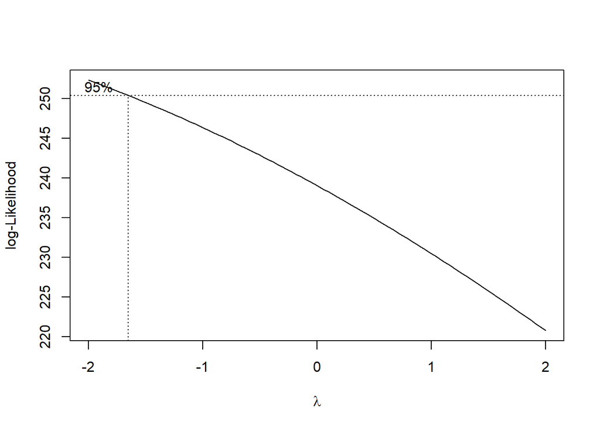

```r
library(MASS)

boxcox(Model1)
```

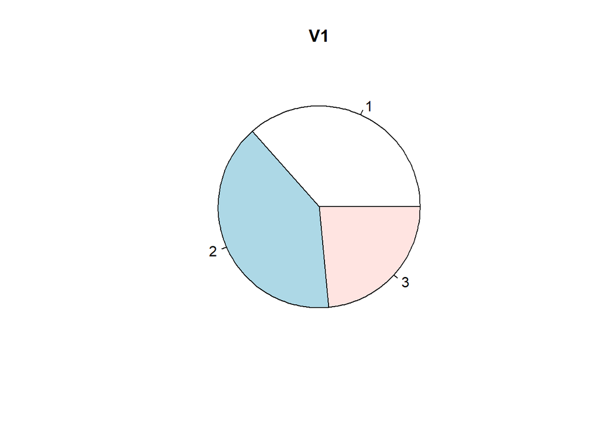

```r
pie(table(data$V1), main = "V1")
```

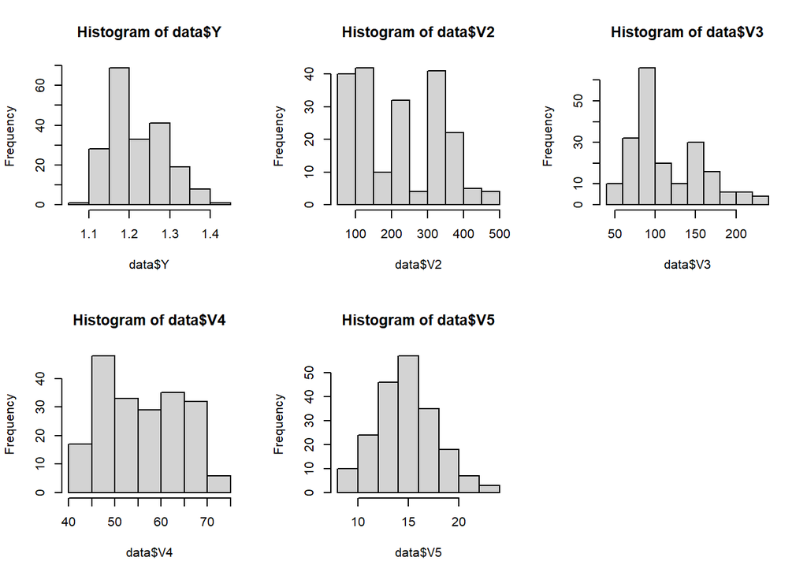

```r
par(mfrow = c(2,3))
hist(data$Y)
hist(data$V2)
hist(data$V3)
hist(data$V4)
hist(data$V5)
```

- **(d) Build a model that satisfies the following requirements and briefly describe how you reach this model:**
  1. The number of regression coefficients in the model is no more than $10$;
  2. Model assumptions hold (reasonably) well;
  3. The adjusted coefficient of multiple determination is at least $0.89$.

*(Note: even if you can not get a model that satisfies all the requirements, you may still get partial credits if your steps make sense. So try your best!)*

```r
# (d). (Type your code in the space below)
library("leaps")

subs <- regsubsets(Y~.^2, data = data, nbest = 10, nvmax = 10, method = "exhaustive")
subsummary <- summary(subs)

subrsq2 <- cbind(subsummary$which, subsummary$adjr2)
colnames(subrsq2) <- c(colnames(subsummary$which), "RSq-adj")
subrsq2
```

```
##    (Intercept) V12 V13 V2 V3 V4 V5 V12:V2 V13:V2 V12:V3 V13:V3 V12:V4 V13:V4
## 1            1   0   0  0  0  1  0      0      0      0      0      0      0
## 1            1   0   0  1  0  0  0      0      0      0      0      0      0
## 1            1   0   0  0  0  0  0      0      0      0      0      0      0
## 1            1   0   0  0  0  0  0      0      0      0      0      0      0
## 1            1   0   0  0  0  0  0      0      0      0      0      0      0
## 1            1   1   0  0  0  0  0      0      0      0      0      0      0
## 1            1   0   0  0  0  0  0      0      0      0      0      0      0
## 1            1   0   0  0  0  0  0      0      0      0      0      0      0
## 1            1   0   0  0  1  0  0      0      0      0      0      0      0
## 1            1   0   0  0  0  0  0      0      0      0      0      0      0
## 2            1   1   0  0  0  1  0      0      0      0      0      0      0
## 2            1   0   0  0  0  1  0      0      0      0      0      0      0
## 2            1   0   0  0  0  1  0      0      0      0      0      1      0
## 2            1   0   0  0  0  1  0      0      0      1      0      0      0
```

[output cut: 187 more lines]

```r
summary(lm(formula = Y ~ V1 + V2 + V3 + V5 + V1:V4 + V4:V5, data = data))
```

```
##
## Call:
## lm(formula = Y ~ V1 + V2 + V3 + V5 + V1:V4 + V4:V5, data = data)
##
## Residuals:
##       Min        1Q    Median        3Q       Max
## -0.067686 -0.015676 -0.000643  0.015610  0.061987
##
## Coefficients:
##               Estimate Std. Error t value Pr(>|t|)
## (Intercept)  1.177e+00  9.986e-02  11.790  < 2e-16 ***
## V12          4.478e-01  7.298e-02   6.136 4.83e-09 ***
## V13         -8.170e-02  8.223e-02  -0.994  0.32170
## V2          -1.872e-04  7.733e-05  -2.420  0.01646 *
## V3          -3.656e-04  1.238e-04  -2.953  0.00354 **
## V5           9.610e-03  6.261e-03   1.535  0.12647
## V11:V4       3.092e-03  2.062e-03   1.499  0.13545
## V12:V4      -4.766e-03  2.479e-03  -1.922  0.05606 .
## V13:V4       5.020e-03  2.676e-03   1.876  0.06222 .
## V5:V4       -2.733e-04  1.185e-04  -2.306  0.02218 *
## ---
## Signif. codes:  0 '***' 0.001 '**' 0.01 '*' 0.05 '.' 0.1 ' ' 1
##
## Residual standard error: 0.02389 on 190 degrees of freedom
## Multiple R-squared:  0.8955, Adjusted R-squared:  0.8905
## F-statistic: 180.9 on 9 and 190 DF,  p-value: < 2.2e-16
```

*(Type your answer here) (d):* I used the Regsubsets function to explore all interaction terms and return the top 10 hits with a max number of variables up to 10 through best subset selection. Despite finding quite a lot of models with adjusted R-sq above 0.89, I had great difficulty encoding some V1 interaction terms while excluding others, so I settled on the model outputted in the code which is Y ~ V1 + V2 + V3 + V5 + V1:V4 + V4:V5, with V1:V4 and V4:V5 being the only interaction terms. As such here there are 9 variables (not including intercept) and the Adjusted R-squared for this model is 0.8905. I considered using the stepAIC function to search but I felt it was not in the spirit of the quiz to search using a different criterion even though it would certainly have yielded a better, more clear result.